# Data Cleaning

Noah Moyer

2023-01-27

### Packages

```r
library(here)
library(readxl)
library(writexl)
library(dplyr) #for pipe function
library(visdat) #for visualizing missing data
```

### Read in data

First, we read in all of the various specific race result data and merge the datasets to create our final dataset.

```r
Omloop <- read_excel(here("Project", "rawData", "AllRaceResults", "2_Omloop.xlsx"))
Omloop$raceName <- "Omloop"
Omloop <- select(Omloop, Rnk, Rider, raceName)

Strade <- read_excel(here("Project", "rawData", "AllRaceResults", "3_strade.xlsx"))
Strade$raceName <- "Strade"

#use this to combine datasets
raceResults <- select(Strade, Rnk, Rider, raceName) %>% rbind(Omloop)

MSR <- read_excel(here("Project", "rawData", "AllRaceResults", "6_MSR.xlsx"))
MSR$raceName <- "MSR"
raceResults <- select(MSR, Rnk, Rider, raceName) %>% rbind(raceResults)

BruggeDePanne <- read_excel(here("Project", "rawData", "AllRaceResults", "8_BruggeDePanne.xlsx"))
BruggeDePanne$raceName <- "BruggeDePanne"
raceResults <- select(BruggeDePanne, Rnk, Rider, raceName) %>% rbind(raceResults)

E3 <- read_excel(here("Project", "rawData", "AllRaceResults", "9_E3.xlsx"))
E3$raceName <- "E3"
raceResults <- select(E3, Rnk, Rider, raceName) %>% rbind(raceResults)

GentWevelgem <- read_excel(here("Project", "rawData", "AllRaceResults", "10_GentWevelgem.xlsx"))
GentWevelgem$raceName <- "GentWevelgem"
raceResults <- select(GentWevelgem, Rnk, Rider, raceName) %>% rbind(raceResults)

DwarsDoor <- read_excel(here("Project", "rawData", "AllRaceResults", "11_DwarsDoor.xlsx"))
DwarsDoor$raceName <- "DwarsDoor"
raceResults <- select(DwarsDoor, Rnk, Rider, raceName) %>% rbind(raceResults)

RVV <- read_excel(here("Project", "rawData", "AllRaceResults", "12_RVV.xlsx"))
RVV$raceName <- "RVV"
raceResults <- select(RVV, Rnk, Rider, raceName) %>% rbind(raceResults)

AmstelGold <- read_excel(here("Project", "rawData", "AllRaceResults", "14_AmstelGold.xlsx"))
AmstelGold$raceName <- "AmstelGold"
raceResults <- select(AmstelGold, Rnk, Rider, raceName) %>% rbind(raceResults)

ParisRoubaix <- read_excel(here("Project", "rawData", "AllRaceResults", "15_ParisRoubaix.xlsx"))
ParisRoubaix$raceName <- "ParisRoubaix"
raceResults <- select(ParisRoubaix, Rnk, Rider, raceName) %>% rbind(raceResults)

Fleche <- read_excel(here("Project", "rawData", "AllRaceResults", "16_Fleche.xlsx"))
Fleche$raceName <- "Fleche"
raceResults <- select(Fleche, Rnk, Rider, raceName) %>% rbind(raceResults)

LBL <- read_excel(here("Project", "rawData", "AllRaceResults", "17_LBL.xlsx"))
LBL$raceName <- "LBL"
raceResults <- select(LBL, Rnk, Rider, raceName) %>% rbind(raceResults)

EschbornFrankfurt <- read_excel(here("Project", "rawData", "AllRaceResults", "19_EschbornFrankfurt.xlsx"))
EschbornFrankfurt$raceName <- "EschbornFrankfurt"
raceResults <- select(EschbornFrankfurt, Rnk, Rider, raceName) %>% rbind(raceResults)

SanSebastian <- read_excel(here("Project", "rawData", "AllRaceResults", "24_SanSebastian.xlsx"))
SanSebastian$raceName <- "SanSebastian"
raceResults <- select(SanSebastian, Rnk, Rider, raceName) %>% rbind(raceResults)

Bemer <- read_excel(here("Project", "rawData", "AllRaceResults", "27_Bemer.xlsx"))
Bemer$raceName <- "Bemer"
raceResults <- select(Bemer, Rnk, Rider, raceName) %>% rbind(raceResults)

Bretagne <- read_excel(here("Project", "rawData", "AllRaceResults", "28_Bretagne.xlsx"))
Bretagne$raceName <- "Bretagne"
raceResults <- select(Bretagne, Rnk, Rider, raceName) %>% rbind(raceResults)

Quebec <- read_excel(here("Project", "rawData", "AllRaceResults", "29_Quebec.xlsx"))
Quebec$raceName <- "Quebec"
raceResults <- select(Quebec, Rnk, Rider, raceName) %>% rbind(raceResults)

Montreal <- read_excel(here("Project", "rawData", "AllRaceResults", "30_Montreal.xlsx"))
Montreal$raceName <- "Montreal"
raceResults <- select(Montreal, Rnk, Rider, raceName) %>% rbind(raceResults)

Lombardia <- read_excel(here("Project", "rawData", "AllRaceResults", "31_Lombardia.xlsx"))
Lombardia$raceName <- "Lombardia"
raceResults <- select(Lombardia, Rnk, Rider, raceName) %>% rbind(raceResults)

UAEStage1 <- read_excel(here("Project", "rawData", "AllRaceResults", "1_UAE", "UAEStage1.xlsx"))
UAEStage1$raceName <- "UAEStage1"
raceResults <- select(UAEStage1, Rnk, Rider, raceName) %>% rbind(raceResults)

UAEStage2 <- read_excel(here("Project", "rawData", "AllRaceResults", "1_UAE", "UAEStage2.xlsx"))
UAEStage2$raceName <- "UAEStage2"
raceResults <- select(UAEStage2, Rnk, Rider, raceName) %>% rbind(raceResults)

UAEStage3 <- read_excel(here("Project", "rawData", "AllRaceResults", "1_UAE", "UAEStage3.xlsx"))
UAEStage3$raceName <- "UAEStage3"
raceResults <- select(UAEStage3, Rnk, Rider, raceName) %>% rbind(raceResults)

UAEStage4 <- read_excel(here("Project", "rawData", "AllRaceResults", "1_UAE", "UAEStage4.xlsx"))
UAEStage4$raceName <- "UAEStage4"
raceResults <- select(UAEStage4, Rnk, Rider, raceName) %>% rbind(raceResults)

UAEStage5 <- read_excel(here("Project", "rawData", "AllRaceResults", "1_UAE", "UAEStage5.xlsx"))
UAEStage5$raceName <- "UAEStage5"
raceResults <- select(UAEStage5, Rnk, Rider, raceName) %>% rbind(raceResults)

UAEStage6 <- read_excel(here("Project", "rawData", "AllRaceResults", "1_UAE", "UAEStage6.xlsx"))
UAEStage6$raceName <- "UAEStage6"
raceResults <- select(UAEStage6, Rnk, Rider, raceName) %>% rbind(raceResults)

UAEStage7 <- read_excel(here("Project", "rawData", "AllRaceResults", "1_UAE", "UAEStage7.xlsx"))
UAEStage7$raceName <- "UAEStage7"
raceResults <- select(UAEStage7, Rnk, Rider, raceName) %>% rbind(raceResults)

ParisNiceStage1 <- read_excel(here("Project", "rawData", "AllRaceResults", "4_ParisNice", "ParisNiceStage1.xlsx"))
ParisNiceStage1$raceName <- "ParisNiceStage1"
raceResults <- select(ParisNiceStage1, Rnk, Rider, raceName) %>% rbind(raceResults)

ParisNiceStage2 <- read_excel(here("Project", "rawData", "AllRaceResults", "4_ParisNice", "ParisNiceStage2.xlsx"))
ParisNiceStage2$raceName <- "ParisNiceStage2"
raceResults <- select(ParisNiceStage2, Rnk, Rider, raceName) %>% rbind(raceResults)

ParisNiceStage3 <- read_excel(here("Project", "rawData", "AllRaceResults", "4_ParisNice", "ParisNiceStage3.xlsx"))
ParisNiceStage3$raceName <- "ParisNiceStage3"
raceResults <- select(ParisNiceStage3, Rnk, Rider, raceName) %>% rbind(raceResults)

ParisNiceStage4 <- read_excel(here("Project", "rawData", "AllRaceResults", "4_ParisNice", "ParisNiceStage4.xlsx"))
ParisNiceStage4$raceName <- "ParisNiceStage4"
raceResults <- select(ParisNiceStage4, Rnk, Rider, raceName) %>% rbind(raceResults)
```

```r
ParisNiceStage5 <- read_excel(here("Project", "rawData", "AllRaceResults", "4_ParisNice", "ParisNiceStage5.xlsx"))
ParisNiceStage5$raceName <- "ParisNiceStage5"
raceResults <- select(ParisNiceStage5, Rnk, Rider, raceName) %>% rbind(raceResults)

ParisNiceStage6 <- read_excel(here("Project", "rawData", "AllRaceResults", "4_ParisNice", "ParisNiceStage6.xlsx"))
ParisNiceStage6$raceName <- "ParisNiceStage6"
raceResults <- select(ParisNiceStage6, Rnk, Rider, raceName) %>% rbind(raceResults)

ParisNiceStage7 <- read_excel(here("Project", "rawData", "AllRaceResults", "4_ParisNice", "ParisNiceStage7.xlsx"))
ParisNiceStage7$raceName <- "ParisNiceStage7"
raceResults <- select(ParisNiceStage7, Rnk, Rider, raceName) %>% rbind(raceResults)

ParisNiceStage8 <- read_excel(here("Project", "rawData", "AllRaceResults", "4_ParisNice", "ParisNiceStage8.xlsx"))
ParisNiceStage8$raceName <- "ParisNiceStage8"
raceResults <- select(ParisNiceStage8, Rnk, Rider, raceName) %>% rbind(raceResults)

TirrenoStage1 <- read_excel(here("Project", "rawData", "AllRaceResults", "5_Tirreno", "TirrenoStage1.xlsx"))
TirrenoStage1$raceName <- "TirrenoStage1"
raceResults <- select(TirrenoStage1, Rnk, Rider, raceName) %>% rbind(raceResults)

TirrenoStage2 <- read_excel(here("Project", "rawData", "AllRaceResults", "5_Tirreno", "TirrenoStage2.xlsx"))
TirrenoStage2$raceName <- "TirrenoStage2"
raceResults <- select(TirrenoStage2, Rnk, Rider, raceName) %>% rbind(raceResults)

TirrenoStage3 <- read_excel(here("Project", "rawData", "AllRaceResults", "5_Tirreno", "TirrenoStage3.xlsx"))
TirrenoStage3$raceName <- "TirrenoStage3"
raceResults <- select(TirrenoStage3, Rnk, Rider, raceName) %>% rbind(raceResults)

TirrenoStage4 <- read_excel(here("Project", "rawData", "AllRaceResults", "5_Tirreno", "TirrenoStage4.xlsx"))
TirrenoStage4$raceName <- "TirrenoStage4"
raceResults <- select(TirrenoStage4, Rnk, Rider, raceName) %>% rbind(raceResults)

TirrenoStage5 <- read_excel(here("Project", "rawData", "AllRaceResults", "5_Tirreno", "TirrenoStage5.xlsx"))
TirrenoStage5$raceName <- "TirrenoStage5"
raceResults <- select(TirrenoStage5, Rnk, Rider, raceName) %>% rbind(raceResults)

TirrenoStage6 <- read_excel(here("Project", "rawData", "AllRaceResults", "5_Tirreno", "TirrenoStage6.xlsx"))
TirrenoStage6$raceName <- "TirrenoStage6"
raceResults <- select(TirrenoStage6, Rnk, Rider, raceName) %>% rbind(raceResults)

TirrenoStage7 <- read_excel(here("Project", "rawData", "AllRaceResults", "5_Tirreno", "TirrenoStage7.xlsx"))
TirrenoStage7$raceName <- "TirrenoStage7"
raceResults <- select(TirrenoStage7, Rnk, Rider, raceName) %>% rbind(raceResults)

CatalunyaStage1 <- read_excel(here("Project", "rawData", "AllRaceResults", "7_Catalunya", "CatalunyaStage1.xlsx"))
CatalunyaStage1$raceName <- "CatalunyaStage1"
raceResults <- select(CatalunyaStage1, Rnk, Rider, raceName) %>% rbind(raceResults)

CatalunyaStage2 <- read_excel(here("Project", "rawData", "AllRaceResults", "7_Catalunya", "CatalunyaStage2.xlsx"))
CatalunyaStage2$raceName <- "CatalunyaStage2"
raceResults <- select(CatalunyaStage2, Rnk, Rider, raceName) %>% rbind(raceResults)

CatalunyaStage3 <- read_excel(here("Project", "rawData", "AllRaceResults", "7_Catalunya", "CatalunyaStage3.xlsx"))
CatalunyaStage3$raceName <- "CatalunyaStage3"
raceResults <- select(CatalunyaStage3, Rnk, Rider, raceName) %>% rbind(raceResults)

CatalunyaStage4 <- read_excel(here("Project", "rawData", "AllRaceResults", "7_Catalunya", "CatalunyaStage4.xlsx"))
CatalunyaStage4$raceName <- "CatalunyaStage4"
raceResults <- select(CatalunyaStage4, Rnk, Rider, raceName) %>% rbind(raceResults)

CatalunyaStage5 <- read_excel(here("Project", "rawData", "AllRaceResults", "7_Catalunya", "CatalunyaStage5.xlsx"))
CatalunyaStage5$raceName <- "CatalunyaStage5"
raceResults <- select(CatalunyaStage5, Rnk, Rider, raceName) %>% rbind(raceResults)

CatalunyaStage6 <- read_excel(here("Project", "rawData", "AllRaceResults", "7_Catalunya", "CatalunyaStage6.xlsx"))
CatalunyaStage6$raceName <- "CatalunyaStage6"
raceResults <- select(CatalunyaStage6, Rnk, Rider, raceName) %>% rbind(raceResults)

CatalunyaStage7 <- read_excel(here("Project", "rawData", "AllRaceResults", "7_Catalunya", "CatalunyaStage7.xlsx"))
CatalunyaStage7$raceName <- "CatalunyaStage7"
raceResults <- select(CatalunyaStage7, Rnk, Rider, raceName) %>% rbind(raceResults)

ItzuliaStage1 <- read_excel(here("Project", "rawData", "AllRaceResults", "13_Itzulia", "ItzuliaStage1.xlsx"))
ItzuliaStage1$raceName <- "ItzuliaStage1"
raceResults <- select(ItzuliaStage1, Rnk, Rider, raceName) %>% rbind(raceResults)

ItzuliaStage2 <- read_excel(here("Project", "rawData", "AllRaceResults", "13_Itzulia", "ItzuliaStage2.xlsx"))
ItzuliaStage2$raceName <- "ItzuliaStage2"
raceResults <- select(ItzuliaStage2, Rnk, Rider, raceName) %>% rbind(raceResults)

ItzuliaStage3 <- read_excel(here("Project", "rawData", "AllRaceResults", "13_Itzulia", "ItzuliaStage3.xlsx"))
ItzuliaStage3$raceName <- "ItzuliaStage3"
raceResults <- select(ItzuliaStage3, Rnk, Rider, raceName) %>% rbind(raceResults)

ItzuliaStage4 <- read_excel(here("Project", "rawData", "AllRaceResults", "13_Itzulia", "ItzuliaStage4.xlsx"))
ItzuliaStage4$raceName <- "ItzuliaStage4"
raceResults <- select(ItzuliaStage4, Rnk, Rider, raceName) %>% rbind(raceResults)

ItzuliaStage5 <- read_excel(here("Project", "rawData", "AllRaceResults", "13_Itzulia", "ItzuliaStage5.xlsx"))
ItzuliaStage5$raceName <- "ItzuliaStage5"
raceResults <- select(ItzuliaStage5, Rnk, Rider, raceName) %>% rbind(raceResults)

ItzuliaStage6 <- read_excel(here("Project", "rawData", "AllRaceResults", "13_Itzulia", "ItzuliaStage6.xlsx"))
ItzuliaStage6$raceName <- "ItzuliaStage6"
raceResults <- select(ItzuliaStage6, Rnk, Rider, raceName) %>% rbind(raceResults)

RomandiePrologue <- read_excel(here("Project", "rawData", "AllRaceResults", "18_Romandie", "RomandiePrologue.xlsx"))
RomandiePrologue$raceName <- "RomandiePrologue"
raceResults <- select(RomandiePrologue, Rnk, Rider, raceName) %>% rbind(raceResults)
```

```r
RomandieStage1 <- read_excel(here("Project", "rawData", "AllRaceResults", "18_Romandie", "RomandieStage1.xlsx"))
RomandieStage1$raceName <- "RomandieStage1"
raceResults <- select(RomandieStage1, Rnk, Rider, raceName) %>% rbind(raceResults)

RomandieStage2 <- read_excel(here("Project", "rawData", "AllRaceResults", "18_Romandie", "RomandieStage2.xlsx"))
RomandieStage2$raceName <- "RomandieStage2"
raceResults <- select(RomandieStage2, Rnk, Rider, raceName) %>% rbind(raceResults)

RomandieStage3 <- read_excel(here("Project", "rawData", "AllRaceResults", "18_Romandie", "RomandieStage3.xlsx"))
RomandieStage3$raceName <- "RomandieStage3"
raceResults <- select(RomandieStage3, Rnk, Rider, raceName) %>% rbind(raceResults)

RomandieStage4 <- read_excel(here("Project", "rawData", "AllRaceResults", "18_Romandie", "RomandieStage4.xlsx"))
RomandieStage4$raceName <- "RomandieStage4"
raceResults <- select(RomandieStage4, Rnk, Rider, raceName) %>% rbind(raceResults)

RomandieStage5 <- read_excel(here("Project", "rawData", "AllRaceResults", "18_Romandie", "RomandieStage5.xlsx"))
RomandieStage5$raceName <- "RomandieStage5"
raceResults <- select(RomandieStage5, Rnk, Rider, raceName) %>% rbind(raceResults)

GiroStage1 <- read_excel(here("Project", "rawData", "AllRaceResults", "20_Giro", "GiroStage1.xlsx"))
GiroStage1$raceName <- "GiroStage1"
raceResults <- select(GiroStage1, Rnk, Rider, raceName) %>% rbind(raceResults)

GiroStage2 <- read_excel(here("Project", "rawData", "AllRaceResults", "20_Giro", "GiroStage2.xlsx"))
GiroStage2$raceName <- "GiroStage2"
raceResults <- select(GiroStage2, Rnk, Rider, raceName) %>% rbind(raceResults)

GiroStage3 <- read_excel(here("Project", "rawData", "AllRaceResults", "20_Giro", "GiroStage3.xlsx"))
GiroStage3$raceName <- "GiroStage3"
raceResults <- select(GiroStage3, Rnk, Rider, raceName) %>% rbind(raceResults)

GiroStage4 <- read_excel(here("Project", "rawData", "AllRaceResults", "20_Giro", "GiroStage4.xlsx"))
GiroStage4$raceName <- "GiroStage4"
raceResults <- select(GiroStage4, Rnk, Rider, raceName) %>% rbind(raceResults)

GiroStage5 <- read_excel(here("Project", "rawData", "AllRaceResults", "20_Giro", "GiroStage5.xlsx"))
GiroStage5$raceName <- "GiroStage5"
raceResults <- select(GiroStage5, Rnk, Rider, raceName) %>% rbind(raceResults)

GiroStage6 <- read_excel(here("Project", "rawData", "AllRaceResults", "20_Giro", "GiroStage6.xlsx"))
GiroStage6$raceName <- "GiroStage6"
raceResults <- select(GiroStage6, Rnk, Rider, raceName) %>% rbind(raceResults)

GiroStage7 <- read_excel(here("Project", "rawData", "AllRaceResults", "20_Giro", "GiroStage7.xlsx"))
GiroStage7$raceName <- "GiroStage7"
raceResults <- select(GiroStage7, Rnk, Rider, raceName) %>% rbind(raceResults)

GiroStage8 <- read_excel(here("Project", "rawData", "AllRaceResults", "20_Giro", "GiroStage8.xlsx"))
GiroStage8$raceName <- "GiroStage8"
raceResults <- select(GiroStage8, Rnk, Rider, raceName) %>% rbind(raceResults)

GiroStage9 <- read_excel(here("Project", "rawData", "AllRaceResults", "20_Giro", "GiroStage9.xlsx"))
GiroStage9$raceName <- "GiroStage9"
raceResults <- select(GiroStage9, Rnk, Rider, raceName) %>% rbind(raceResults)

GiroStage10 <- read_excel(here("Project", "rawData", "AllRaceResults", "20_Giro", "GiroStage10.xlsx"))
GiroStage10$raceName <- "GiroStage10"
raceResults <- select(GiroStage10, Rnk, Rider, raceName) %>% rbind(raceResults)

GiroStage11 <- read_excel(here("Project", "rawData", "AllRaceResults", "20_Giro", "GiroStage11.xlsx"))
GiroStage11$raceName <- "GiroStage11"
raceResults <- select(GiroStage11, Rnk, Rider, raceName) %>% rbind(raceResults)

GiroStage12 <- read_excel(here("Project", "rawData", "AllRaceResults", "20_Giro", "GiroStage12.xlsx"))
GiroStage12$raceName <- "GiroStage12"
raceResults <- select(GiroStage12, Rnk, Rider, raceName) %>% rbind(raceResults)

GiroStage13 <- read_excel(here("Project", "rawData", "AllRaceResults", "20_Giro", "GiroStage13.xlsx"))
GiroStage13$raceName <- "GiroStage13"
raceResults <- select(GiroStage13, Rnk, Rider, raceName) %>% rbind(raceResults)

GiroStage14 <- read_excel(here("Project", "rawData", "AllRaceResults", "20_Giro", "GiroStage14.xlsx"))
GiroStage14$raceName <- "GiroStage14"
raceResults <- select(GiroStage14, Rnk, Rider, raceName) %>% rbind(raceResults)

GiroStage15 <- read_excel(here("Project", "rawData", "AllRaceResults", "20_Giro", "GiroStage15.xlsx"))
GiroStage15$raceName <- "GiroStage15"
raceResults <- select(GiroStage15, Rnk, Rider, raceName) %>% rbind(raceResults)

GiroStage16 <- read_excel(here("Project", "rawData", "AllRaceResults", "20_Giro", "GiroStage16.xlsx"))
GiroStage16$raceName <- "GiroStage16"
raceResults <- select(GiroStage16, Rnk, Rider, raceName) %>% rbind(raceResults)

GiroStage17 <- read_excel(here("Project", "rawData", "AllRaceResults", "20_Giro", "GiroStage17.xlsx"))
GiroStage17$raceName <- "GiroStage17"
raceResults <- select(GiroStage17, Rnk, Rider, raceName) %>% rbind(raceResults)

GiroStage18 <- read_excel(here("Project", "rawData", "AllRaceResults", "20_Giro", "GiroStage18.xlsx"))
GiroStage18$raceName <- "GiroStage18"
raceResults <- select(GiroStage18, Rnk, Rider, raceName) %>% rbind(raceResults)

GiroStage19 <- read_excel(here("Project", "rawData", "AllRaceResults", "20_Giro", "GiroStage19.xlsx"))
GiroStage19$raceName <- "GiroStage19"
raceResults <- select(GiroStage19, Rnk, Rider, raceName) %>% rbind(raceResults)

GiroStage20 <- read_excel(here("Project", "rawData", "AllRaceResults", "20_Giro", "GiroStage20.xlsx"))
GiroStage20$raceName <- "GiroStage20"
raceResults <- select(GiroStage20, Rnk, Rider, raceName) %>% rbind(raceResults)

GiroStage21 <- read_excel(here("Project", "rawData", "AllRaceResults", "20_Giro", "GiroStage21.xlsx"))
GiroStage21$raceName <- "GiroStage21"
raceResults <- select(GiroStage21, Rnk, Rider, raceName) %>% rbind(raceResults)

DauphineStage1 <- read_excel(here("Project", "rawData", "AllRaceResults", "21_Dauphine", "DauphineStage1.xlsx"))
DauphineStage1$raceName <- "DauphineStage1"
raceResults <- select(DauphineStage1, Rnk, Rider, raceName) %>% rbind(raceResults)
```

```r
DauphineStage2 <- read_excel(here("Project", "rawData", "AllRaceResults", "21_Dauphine", "DauphineStage2.xlsx"))
DauphineStage2$raceName <- "DauphineStage2"
raceResults <- select(DauphineStage2, Rnk, Rider, raceName) %>% rbind(raceResults)

DauphineStage3 <- read_excel(here("Project", "rawData", "AllRaceResults", "21_Dauphine", "DauphineStage3.xlsx"))
DauphineStage3$raceName <- "DauphineStage3"
raceResults <- select(DauphineStage3, Rnk, Rider, raceName) %>% rbind(raceResults)

DauphineStage4 <- read_excel(here("Project", "rawData", "AllRaceResults", "21_Dauphine", "DauphineStage4.xlsx"))
DauphineStage4$raceName <- "DauphineStage4"
raceResults <- select(DauphineStage4, Rnk, Rider, raceName) %>% rbind(raceResults)

DauphineStage5 <- read_excel(here("Project", "rawData", "AllRaceResults", "21_Dauphine", "DauphineStage5.xlsx"))
DauphineStage5$raceName <- "DauphineStage5"
raceResults <- select(DauphineStage5, Rnk, Rider, raceName) %>% rbind(raceResults)

DauphineStage6 <- read_excel(here("Project", "rawData", "AllRaceResults", "21_Dauphine", "DauphineStage6.xlsx"))
DauphineStage6$raceName <- "DauphineStage6"
raceResults <- select(DauphineStage6, Rnk, Rider, raceName) %>% rbind(raceResults)

DauphineStage7 <- read_excel(here("Project", "rawData", "AllRaceResults", "21_Dauphine", "DauphineStage7.xlsx"))
DauphineStage7$raceName <- "DauphineStage7"
raceResults <- select(DauphineStage7, Rnk, Rider, raceName) %>% rbind(raceResults)

DauphineStage8 <- read_excel(here("Project", "rawData", "AllRaceResults", "21_Dauphine", "DauphineStage8.xlsx"))
DauphineStage8$raceName <- "DauphineStage8"
raceResults <- select(DauphineStage8, Rnk, Rider, raceName) %>% rbind(raceResults)

SuisseStage1 <- read_excel(here("Project", "rawData", "AllRaceResults", "22_Suisse", "SuisseStage1.xlsx"))
SuisseStage1$raceName <- "SuisseStage1"
raceResults <- select(SuisseStage1, Rnk, Rider, raceName) %>% rbind(raceResults)

SuisseStage2 <- read_excel(here("Project", "rawData", "AllRaceResults", "22_Suisse", "SuisseStage2.xlsx"))
SuisseStage2$raceName <- "SuisseStage2"
raceResults <- select(SuisseStage2, Rnk, Rider, raceName) %>% rbind(raceResults)

SuisseStage3 <- read_excel(here("Project", "rawData", "AllRaceResults", "22_Suisse", "SuisseStage3.xlsx"))
SuisseStage3$raceName <- "SuisseStage3"
raceResults <- select(SuisseStage3, Rnk, Rider, raceName) %>% rbind(raceResults)

SuisseStage4 <- read_excel(here("Project", "rawData", "AllRaceResults", "22_Suisse", "SuisseStage4.xlsx"))
SuisseStage4$raceName <- "SuisseStage4"
raceResults <- select(SuisseStage4, Rnk, Rider, raceName) %>% rbind(raceResults)

SuisseStage5 <- read_excel(here("Project", "rawData", "AllRaceResults", "22_Suisse", "SuisseStage5.xlsx"))
SuisseStage5$raceName <- "SuisseStage5"
raceResults <- select(SuisseStage5, Rnk, Rider, raceName) %>% rbind(raceResults)

SuisseStage6 <- read_excel(here("Project", "rawData", "AllRaceResults", "22_Suisse", "SuisseStage6.xlsx"))
SuisseStage6$raceName <- "SuisseStage6"
raceResults <- select(SuisseStage6, Rnk, Rider, raceName) %>% rbind(raceResults)

SuisseStage7 <- read_excel(here("Project", "rawData", "AllRaceResults", "22_Suisse", "SuisseStage7.xlsx"))
SuisseStage7$raceName <- "SuisseStage7"
raceResults <- select(SuisseStage7, Rnk, Rider, raceName) %>% rbind(raceResults)

SuisseStage8 <- read_excel(here("Project", "rawData", "AllRaceResults", "22_Suisse", "SuisseStage8.xlsx"))
SuisseStage8$raceName <- "SuisseStage8"
raceResults <- select(SuisseStage8, Rnk, Rider, raceName) %>% rbind(raceResults)

TDFStage1 <- read_excel(here("Project", "rawData", "AllRaceResults", "23_TDF", "TDFStage1.xlsx"))
TDFStage1$raceName <- "TDFStage1"
raceResults <- select(TDFStage1, Rnk, Rider, raceName) %>% rbind(raceResults)

TDFStage2 <- read_excel(here("Project", "rawData", "AllRaceResults", "23_TDF", "TDFStage2.xlsx"))
TDFStage2$raceName <- "TDFStage2"
raceResults <- select(TDFStage2, Rnk, Rider, raceName) %>% rbind(raceResults)

TDFStage3 <- read_excel(here("Project", "rawData", "AllRaceResults", "23_TDF", "TDFStage3.xlsx"))
TDFStage3$raceName <- "TDFStage3"
raceResults <- select(TDFStage3, Rnk, Rider, raceName) %>% rbind(raceResults)

TDFStage4 <- read_excel(here("Project", "rawData", "AllRaceResults", "23_TDF", "TDFStage4.xlsx"))
TDFStage4$raceName <- "TDFStage4"
raceResults <- select(TDFStage4, Rnk, Rider, raceName) %>% rbind(raceResults)

TDFStage5 <- read_excel(here("Project", "rawData", "AllRaceResults", "23_TDF", "TDFStage5.xlsx"))
TDFStage5$raceName <- "TDFStage5"
raceResults <- select(TDFStage5, Rnk, Rider, raceName) %>% rbind(raceResults)

TDFStage6 <- read_excel(here("Project", "rawData", "AllRaceResults", "23_TDF", "TDFStage6.xlsx"))
TDFStage6$raceName <- "TDFStage6"
raceResults <- select(TDFStage6, Rnk, Rider, raceName) %>% rbind(raceResults)

TDFStage7 <- read_excel(here("Project", "rawData", "AllRaceResults", "23_TDF", "TDFStage7.xlsx"))
TDFStage7$raceName <- "TDFStage7"
raceResults <- select(TDFStage7, Rnk, Rider, raceName) %>% rbind(raceResults)

TDFStage8 <- read_excel(here("Project", "rawData", "AllRaceResults", "23_TDF", "TDFStage8.xlsx"))
TDFStage8$raceName <- "TDFStage8"
raceResults <- select(TDFStage8, Rnk, Rider, raceName) %>% rbind(raceResults)

TDFStage9 <- read_excel(here("Project", "rawData", "AllRaceResults", "23_TDF", "TDFStage9.xlsx"))
TDFStage9$raceName <- "TDFStage9"
raceResults <- select(TDFStage9, Rnk, Rider, raceName) %>% rbind(raceResults)

TDFStage10 <- read_excel(here("Project", "rawData", "AllRaceResults", "23_TDF", "TDFStage10.xlsx"))
TDFStage10$raceName <- "TDFStage10"
raceResults <- select(TDFStage10, Rnk, Rider, raceName) %>% rbind(raceResults)

TDFStage11 <- read_excel(here("Project", "rawData", "AllRaceResults", "23_TDF", "TDFStage11.xlsx"))
TDFStage11$raceName <- "TDFStage11"
raceResults <- select(TDFStage11, Rnk, Rider, raceName) %>% rbind(raceResults)

TDFStage12 <- read_excel(here("Project", "rawData", "AllRaceResults", "23_TDF", "TDFStage12.xlsx"))
TDFStage12$raceName <- "TDFStage12"
raceResults <- select(TDFStage12, Rnk, Rider, raceName) %>% rbind(raceResults)
```

```r
TDFStage13 <- read_excel(here("Project", "rawData", "AllRaceResults", "23_TDF", "TDFStage13.xlsx"))
TDFStage13$raceName <- "TDFStage13"
raceResults <- select(TDFStage13, Rnk, Rider, raceName) %>% rbind(raceResults)

TDFStage14 <- read_excel(here("Project", "rawData", "AllRaceResults", "23_TDF", "TDFStage14.xlsx"))
TDFStage14$raceName <- "TDFStage14"
raceResults <- select(TDFStage14, Rnk, Rider, raceName) %>% rbind(raceResults)

TDFStage15 <- read_excel(here("Project", "rawData", "AllRaceResults", "23_TDF", "TDFStage15.xlsx"))
TDFStage15$raceName <- "TDFStage15"
raceResults <- select(TDFStage15, Rnk, Rider, raceName) %>% rbind(raceResults)

TDFStage16 <- read_excel(here("Project", "rawData", "AllRaceResults", "23_TDF", "TDFStage16.xlsx"))
TDFStage16$raceName <- "TDFStage16"
raceResults <- select(TDFStage16, Rnk, Rider, raceName) %>% rbind(raceResults)

TDFStage17 <- read_excel(here("Project", "rawData", "AllRaceResults", "23_TDF", "TDFStage17.xlsx"))
TDFStage17$raceName <- "TDFStage17"
raceResults <- select(TDFStage17, Rnk, Rider, raceName) %>% rbind(raceResults)

TDFStage18 <- read_excel(here("Project", "rawData", "AllRaceResults", "23_TDF", "TDFStage18.xlsx"))
TDFStage18$raceName <- "TDFStage18"
raceResults <- select(TDFStage18, Rnk, Rider, raceName) %>% rbind(raceResults)

TDFStage19 <- read_excel(here("Project", "rawData", "AllRaceResults", "23_TDF", "TDFStage19.xlsx"))
TDFStage19$raceName <- "TDFStage19"
raceResults <- select(TDFStage19, Rnk, Rider, raceName) %>% rbind(raceResults)

TDFStage20 <- read_excel(here("Project", "rawData", "AllRaceResults", "23_TDF", "TDFStage20.xlsx"))
TDFStage20$raceName <- "TDFStage20"
raceResults <- select(TDFStage20, Rnk, Rider, raceName) %>% rbind(raceResults)

TDFStage21 <- read_excel(here("Project", "rawData", "AllRaceResults", "23_TDF", "TDFStage21.xlsx"))
TDFStage21$raceName <- "TDFStage21"
raceResults <- select(TDFStage21, Rnk, Rider, raceName) %>% rbind(raceResults)

PolandStage1 <- read_excel(here("Project", "rawData", "AllRaceResults", "25_Poland", "PolandStage1.xlsx"))
PolandStage1$raceName <- "PolandStage1"
raceResults <- select(PolandStage1, Rnk, Rider, raceName) %>% rbind(raceResults)

PolandStage2 <- read_excel(here("Project", "rawData", "AllRaceResults", "25_Poland", "PolandStage2.xlsx"))
PolandStage2$raceName <- "PolandStage2"
raceResults <- select(PolandStage2, Rnk, Rider, raceName) %>% rbind(raceResults)

PolandStage3 <- read_excel(here("Project", "rawData", "AllRaceResults", "25_Poland", "PolandStage3.xlsx"))
PolandStage3$raceName <- "PolandStage3"
raceResults <- select(PolandStage3, Rnk, Rider, raceName) %>% rbind(raceResults)

PolandStage4 <- read_excel(here("Project", "rawData", "AllRaceResults", "25_Poland", "PolandStage4.xlsx"))
PolandStage4$raceName <- "PolandStage4"
raceResults <- select(PolandStage4, Rnk, Rider, raceName) %>% rbind(raceResults)

PolandStage5 <- read_excel(here("Project", "rawData", "AllRaceResults", "25_Poland", "PolandStage5.xlsx"))
PolandStage5$raceName <- "PolandStage5"
raceResults <- select(PolandStage5, Rnk, Rider, raceName) %>% rbind(raceResults)

PolandStage6 <- read_excel(here("Project", "rawData", "AllRaceResults", "25_Poland", "PolandStage6.xlsx"))
PolandStage6$raceName <- "PolandStage6"
raceResults <- select(PolandStage6, Rnk, Rider, raceName) %>% rbind(raceResults)

PolandStage7 <- read_excel(here("Project", "rawData", "AllRaceResults", "25_Poland", "PolandStage7.xlsx"))
PolandStage7$raceName <- "PolandStage7"
raceResults <- select(PolandStage7, Rnk, Rider, raceName) %>% rbind(raceResults)

VueltaStage2 <- read_excel(here("Project", "rawData", "AllRaceResults", "26_Vuelta", "VueltaStage2.xlsx"))
VueltaStage2$raceName <- "VueltaStage2"
raceResults <- select(VueltaStage2, Rnk, Rider, raceName) %>% rbind(raceResults)

VueltaStage3 <- read_excel(here("Project", "rawData", "AllRaceResults", "26_Vuelta", "VueltaStage3.xlsx"))
VueltaStage3$raceName <- "VueltaStage3"
raceResults <- select(VueltaStage3, Rnk, Rider, raceName) %>% rbind(raceResults)

VueltaStage4 <- read_excel(here("Project", "rawData", "AllRaceResults", "26_Vuelta", "VueltaStage4.xlsx"))
VueltaStage4$raceName <- "VueltaStage4"
raceResults <- select(VueltaStage4, Rnk, Rider, raceName) %>% rbind(raceResults)

VueltaStage5 <- read_excel(here("Project", "rawData", "AllRaceResults", "26_Vuelta", "VueltaStage5.xlsx"))
VueltaStage5$raceName <- "VueltaStage5"
raceResults <- select(VueltaStage5, Rnk, Rider, raceName) %>% rbind(raceResults)

VueltaStage6 <- read_excel(here("Project", "rawData", "AllRaceResults", "26_Vuelta", "VueltaStage6.xlsx"))
VueltaStage6$raceName <- "VueltaStage6"
raceResults <- select(VueltaStage6, Rnk, Rider, raceName) %>% rbind(raceResults)

VueltaStage7 <- read_excel(here("Project", "rawData", "AllRaceResults", "26_Vuelta", "VueltaStage7.xlsx"))
VueltaStage7$raceName <- "VueltaStage7"
raceResults <- select(VueltaStage7, Rnk, Rider, raceName) %>% rbind(raceResults)

VueltaStage8 <- read_excel(here("Project", "rawData", "AllRaceResults", "26_Vuelta", "VueltaStage8.xlsx"))
VueltaStage8$raceName <- "VueltaStage8"
raceResults <- select(VueltaStage8, Rnk, Rider, raceName) %>% rbind(raceResults)

VueltaStage9 <- read_excel(here("Project", "rawData", "AllRaceResults", "26_Vuelta", "VueltaStage9.xlsx"))
VueltaStage9$raceName <- "VueltaStage9"
raceResults <- select(VueltaStage9, Rnk, Rider, raceName) %>% rbind(raceResults)

VueltaStage10 <- read_excel(here("Project", "rawData", "AllRaceResults", "26_Vuelta", "VueltaStage10.xlsx"))
VueltaStage10$raceName <- "VueltaStage10"
raceResults <- select(VueltaStage10, Rnk, Rider, raceName) %>% rbind(raceResults)

VueltaStage11 <- read_excel(here("Project", "rawData", "AllRaceResults", "26_Vuelta", "VueltaStage11.xlsx"))
VueltaStage11$raceName <- "VueltaStage11"
raceResults <- select(VueltaStage11, Rnk, Rider, raceName) %>% rbind(raceResults)

VueltaStage12 <- read_excel(here("Project", "rawData", "AllRaceResults", "26_Vuelta", "VueltaStage12.xlsx"))
VueltaStage12$raceName <- "VueltaStage12"
raceResults <- select(VueltaStage12, Rnk, Rider, raceName) %>% rbind(raceResults)
```

```r
VueltaStage13 <- read_excel(here("Project", "rawData", "AllRaceResults", "26_Vuelta", "VueltaStage13.xlsx"))
VueltaStage13$raceName <- "VueltaStage13"
raceResults <- select(VueltaStage13, Rnk, Rider, raceName) %>% rbind(raceResults)

VueltaStage14 <- read_excel(here("Project", "rawData", "AllRaceResults", "26_Vuelta", "VueltaStage14.xlsx"))
VueltaStage14$raceName <- "VueltaStage14"
raceResults <- select(VueltaStage14, Rnk, Rider, raceName) %>% rbind(raceResults)

VueltaStage15 <- read_excel(here("Project", "rawData", "AllRaceResults", "26_Vuelta", "VueltaStage15.xlsx"))
VueltaStage15$raceName <- "VueltaStage15"
raceResults <- select(VueltaStage15, Rnk, Rider, raceName) %>% rbind(raceResults)

VueltaStage16 <- read_excel(here("Project", "rawData", "AllRaceResults", "26_Vuelta", "VueltaStage16.xlsx"))
VueltaStage16$raceName <- "VueltaStage16"
raceResults <- select(VueltaStage16, Rnk, Rider, raceName) %>% rbind(raceResults)

VueltaStage17 <- read_excel(here("Project", "rawData", "AllRaceResults", "26_Vuelta", "VueltaStage17.xlsx"))
VueltaStage17$raceName <- "VueltaStage17"
raceResults <- select(VueltaStage17, Rnk, Rider, raceName) %>% rbind(raceResults)

VueltaStage18 <- read_excel(here("Project", "rawData", "AllRaceResults", "26_Vuelta", "VueltaStage18.xlsx"))
VueltaStage18$raceName <- "VueltaStage18"
raceResults <- select(VueltaStage18, Rnk, Rider, raceName) %>% rbind(raceResults)

VueltaStage19 <- read_excel(here("Project", "rawData", "AllRaceResults", "26_Vuelta", "VueltaStage19.xlsx"))
VueltaStage19$raceName <- "VueltaStage19"
raceResults <- select(VueltaStage19, Rnk, Rider, raceName) %>% rbind(raceResults)

VueltaStage20 <- read_excel(here("Project", "rawData", "AllRaceResults", "26_Vuelta", "VueltaStage20.xlsx"))
VueltaStage20$raceName <- "VueltaStage20"
raceResults <- select(VueltaStage20, Rnk, Rider, raceName) %>% rbind(raceResults)

VueltaStage21 <- read_excel(here("Project", "rawData", "AllRaceResults", "26_Vuelta", "VueltaStage21.xlsx"))
VueltaStage21$raceName <- "VueltaStage21"
raceResults <- select(VueltaStage21, Rnk, Rider, raceName) %>% rbind(raceResults)
```

Next, we read in the race profiles and rider profiles. We then merge all of three of these dataframes together to make our final dataframe.

```r
#read in the rider profile excel sheet
riderProfile <- read_excel(here("Project", "rawData", "RiderProfile.xlsx"))

#merge the rider profile df and the race results df
riderPlusRaceResults <- merge(riderProfile, raceResults, by.x="RiderName", by.y="Rider", all=TRUE)

#read in the race profile excel sheet
raceProfile <- read_excel(here("Project", "rawData", "raceProfile.xlsx"))

#merge the previously merged df and the raceProfile df
bikingDF <- merge(riderPlusRaceResults, raceProfile, by.x="raceName", by.y="RaceName")
```

### Dealing with NAs

Now, we need to figure out how to deal with our NAs. Let’s visualize the missing data first.

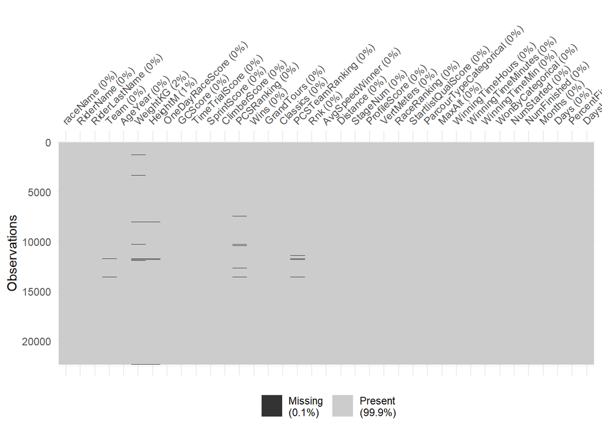

```r
#visualize missing data
vis_miss(bikingDF)
```

Overall, I have a very small amount of missing data. The most significant categories that were missing data was weight and height but even for these the percentage missing is at 2% and 1% respectively. I know from data collection that riders who were missing weight and height values generally did not play huge factors in races in general. There are lots of racers who fall into the category of not being a factor in races so losing these riders from my dataset will not be a big deal. The same goes with missing values in team, PCSRanking, and PCSTeamRanking. Thus, I will now remove all missing value observations. I am also going to remove all DNF, DNS, or OTL observations. The reasons behind receiving a “did not finish”, “did not start”, or “outside of time limit” are beyond the scope of this investigation. This also means that the Rnk column can be numeric.

```r
#convert Rnk column from character entries to numeric entries
bikingDF$Rnk <- as.numeric(bikingDF$Rnk)
#all DNF, DNS, OTL are converted to NAs which are then removed by the na.omit function

#remove rows with NAs
bikingDF <- na.omit(bikingDF)
```

### Exporting our data frames

Now, I will export the bikingDF so they can be used in other files.

```r
#save bikingDF
write_xlsx(bikingDF, here("Project", "rawData", "bikingDF.xlsx"))
```